# P&S-2022: Lab assignment 2

Name1, Name2, Viktoria Toporovska

### Task 3.

#### First, generate samples an sample means:

```r
# id = 3
nu1 <- 13  # id + 10
K <- 1e3 # times to get the sample
n_values <- c(5, 10, 50)  # Sample sizes

n = 50 #test or start size

sample_means <- matrix(rexp(n * K, rate = nu1), nrow = n)
```

```r
mu <- 1/nu1 #we are looking for limits
sigma <-  mu / sqrt(n)
print(mu)
```

```
## [1] 0.07692308
```

```r
print (sigma)
```

```
## [1] 0.01087857
```

#### We can now plot ecdf and cdf

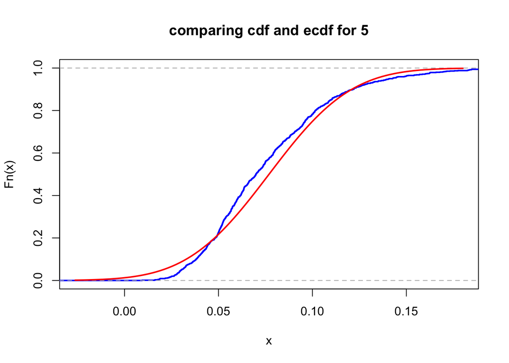

```
## [1] 0.08741495
```

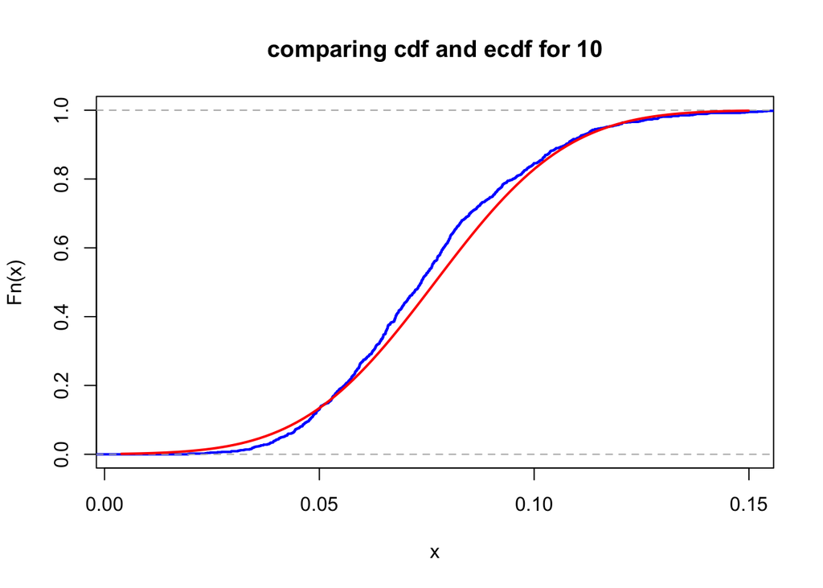

```
## [1] 0.07733719
```

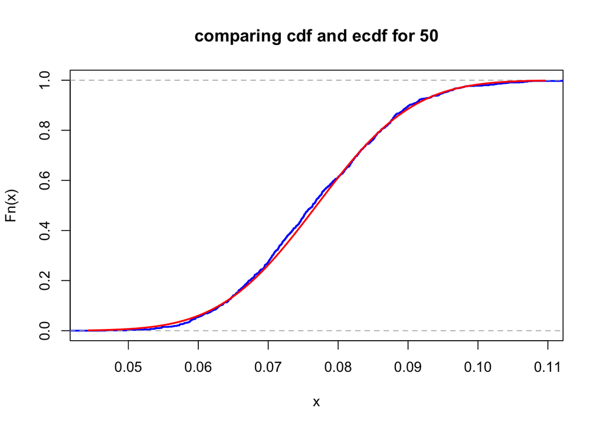

```
## [1] 0.0268099
```

```r
x <- seq(-1,1.200,by=0.001)# set the dimension of the x axis
for (n in n_values) { #passability of the cycle on all elements
  mu <- 1 / nu1 #we are looking for everyone
  sigma <- mu / sqrt(n)

  xlims <- c(mu-3*sigma,mu+3*sigma)


  sample_means <- colMeans(matrix(rexp(n*K, rate = nu1), nrow=n))
  Fs <- ecdf(sample_means)

  title <- paste("comparing cdf and ecdf for", toString(n))
  plot(Fs,
       xlim = xlims,
       col = "blue",
       lwd = 2,
       main = title)

  curve(pnorm(x, mean = mu, sd = sigma), col = "red", lwd = 2, add = TRUE)

  print(max(abs(ecdf(sample_means)(x)-pnorm(x,mean = mu, sd = sigma))))
}
```

1. The place can be considered safe when the number of clicks in one minute does not exceed $100$. It is known that the parameter $\nu$ of the resulting exponential distribution is proportional to the number $N$ of the radioactive samples, i.e., $\nu = \nu_1*N$, where $\nu_1$ is the parameter for one sample. Determine the maximal number of radioactive samples that can be stored in that place so that, with probability $0.95$, the place is identified as safe. To do this,
   - express the event of interest in terms of the $S:= X_1 + \cdots + X_{100}$;
   - obtain the theoretical bounds on $N$ using the Markov inequality, Chernoff bound and Central Limit Theorem and compare the results;
   - with the predicted $N$ and thus $\nu$, simulate the realization $x_1,x_2,\dots,x_{100}$ of the $X_i$ and of the sum $S = X_1 + \cdots + X_{100}$;
   - repeat this $K$ times to get the sample $\mathbf{s}=(s_1,\dots,s_K)$ of total times until the $100^{\mathrm{th}}$ click;
   - estimate the probability that the location is identified as safe and compare to the desired level $0.95$

$S = X_1 + ... + X_{100}$

$P(S>=60)$

**Markov**

$$P(S \ge 1) \le \frac {\mu_S}{1} = \frac {100} {13*N}$$
$$0.95 \le \frac {100} {13*N}$$
$$N=8$$

**Central Limit theorem:**

$$P(\frac {S - 100 * \mu} {\sigma * \sqrt n} \le t) \rightarrow Ф(t)$$

$$\mu_S = \frac {100} {13*N} = \sigma_S$$
$$P(S\ge1) = P(\frac {S - 100 * \frac 1 {13 * N}}{10 * \frac 1 {13 * N}}
\le \frac {1 - 100 * \frac 1 {13 * N}}{10 * \frac 1 {13 * N}}) = Ф(\frac
{13 * N- 100} {10})$$
$$Ф(\frac {13 * N- 100} {10}) \ge 0.95$$

```r
threshold <- 60  # Threshold for safety (total time <= 60 seconds)
desired_prob <- 0.95  # Desired probability of safety

# Step 1: Express the event of interest
# Calculate the probability that the total time taken to accumulate 100 clicks is more than 60 seconds
S_event <- rexp(100, rate = nu1)
S <- sum(S_event)

# Step 2: Theoretical Bounds
# Calculate theoretical bounds on N using Markov, Chernoff, and CLT
# Markov Bound
markov_bound <- 100 / (desired_prob * nu1)  # Upper bound based on Markov inequality

# Chernoff Bound
t <- log(1 / (desired_prob ^ (1/100)))  # Chernoff bound parameter
chernoff_bound <- (t * (exp(1) * desired_prob) ^ (1/100)) / (13 * ((exp(1) * desired_prob) ^ (1/100) - 1))

# CLT Bound
clt_bound <- 100 / (13 * markov_bound)  # Upper bound based on CLT

# Output bounds
cat("Markov Bound:", markov_bound, "\n")
```

```
## Markov Bound: 8.097166
```

```r
cat("Chernoff Bound:", chernoff_bound, "\n")
```

```
## Chernoff Bound: 0.004178724
```

```r
cat("CLT Bound:", clt_bound, "\n")
```

```
## CLT Bound: 0.95
```